# Biostrings and Genomic Data Demo

## Introduction

This document demonstrates the core functionalities of the `Biostrings` package and related Bioconductor packages for sequence analysis, genomic range manipulation, and variant annotation.

### Basic BString Operations

The `Biostrings` package provides efficient containers for string manipulation. The `BString` class is a general-purpose container for large strings.

```r
library(Biostrings)
# Create a basic Biostring object
a = BString("I am a string!")
a
```

```
## 14-letter BString object
## seq: I am a string!
```

```r
# Get the number of characters in the string
length(a)
```

```
## [1] 14
```

```r
# Extract the first 4 characters using standard R indexing
a[1:4]
```

```
## 4-letter BString object
## seq: I am
```

```r
# Extract a subsequence using the subseq function
subseq(a, 1, 4)
```

```
## 4-letter BString object
## seq: I am
```

```r
# Extract a subsequence from the start up to the 4th character
subseq(a, end=4)
```

```
## 4-letter BString object
## seq: I am
```

```r
# Reverse the string (note: this simply reverses characters, it is NOT a biological reverse complement)
rev(a)
```

```
## 14-letter BString object
## seq: !gnirts a ma I
```

```r
# Logical comparisons
a == "I am a string!" # Returns TRUE
```

```
## [1] TRUE
```

```r
a[1:4] == "I am"      # Returns TRUE
```

```
## [1] TRUE
```

```r
# Convert the BString back to a standard R character vector
toString(a)
```

```
## [1] "I am a string!"
```

```r
# Check the object classes
class(a)              # "BString"
```

```
## [1] "BString"
## attr(,"package")
## [1] "Biostrings"
```

```r
class(toString(a))    # "character"
```

```
## [1] "character"
```

### DNA and RNA Strings

For biological data, it is better to use `DNAString` or `RNAString`, which enforce specific biological alphabets and enable specialized operations.

```r
## Inspect built-in biological alphabets and maps
IUPAC_CODE_MAP # Dictionary of IUPAC ambiguity codes
```

```
##      A      C      G      T      M      R      W      S      Y      K      V
##    "A"    "C"    "G"    "T"   "AC"   "AG"   "AT"   "CG"   "CT"   "GT"  "ACG"
##      H      D      B      N
##  "ACT"  "AGT"  "CGT" "ACGT"
```

```r
DNA_ALPHABET   # Allowed characters in a DNAString
```

```
##  [1] "A" "C" "G" "T" "M" "R" "W" "S" "Y" "K" "V" "H" "D" "B" "N" "-" "+" "."
```

```r
DNA_BASES      # The four core DNA bases (A, C, G, T)
```

```
## [1] "A" "C" "G" "T"
```

```r
RNA_ALPHABET   # Allowed characters in an RNAString
```

```
##  [1] "A" "C" "G" "U" "M" "R" "W" "S" "Y" "K" "V" "H" "D" "B" "N" "-" "+" "."
```

```r
RNA_BASES      # The four core RNA bases (A, C, G, U)
```

```
## [1] "A" "C" "G" "U"
```

```r
# Attempting to create a DNAString with non-DNA characters generates an error/warning
# a = DNAString("I am a string") # (Intentionally commented out to prevent error if run)

# Create a valid DNA string
a = DNAString("ATTGCC")
a
```

```
## 6-letter DNAString object
## seq: ATTGCC
```

```r
# Create a valid RNA string
# b = RNAString("ATTGCC") # Warning/Error in strict modes, 'T' is not standard RNA
b = RNAString("AUUGCC") # Correct RNA string
b = RNAString(a)      # Converts the DNAString 'a' into an RNAString (T becomes U automatically)
b
```

```
## 6-letter RNAString object
## seq: AUUGCC
```

```r
# Explore available methods for the DNAStringSet class
methods(class="DNAStringSet") |> head()
```

```
## [1] "!,List-method"           "!=,ANY,Vector-method"
## [3] "!=,Vector,ANY-method"    "!=,Vector,Vector-method"
## [5] "[,List-method"           "[[,List-method"
```

```r
# Bring up the help page for DNAStringSet
?"DNAStringSet"
# Open the Biostrings package vignettes in the browser
# browseVignettes(package="Biostrings")

b
```

```
## 6-letter RNAString object
## seq: AUUGCC
```

```r
a
```

```
## 6-letter DNAString object
## seq: ATTGCC
```

```r
length(a) # Length of the DNA sequence
```

```
## [1] 6
```

```r
a[1:3]    # Subset the first 3 nucleotides
```

```
## 3-letter DNAString object
## seq: ATT
```

### Sequence Frequencies and Complements

`Biostrings` provides optimized functions to count base frequencies and compute complements.

```r
## frequencies
# Count occurrences of all letters in the DNA alphabet
alphabetFrequency(a)
```

```
## A C G T M R W S Y K V H D B N - + .
## 1 2 1 2 0 0 0 0 0 0 0 0 0 0 0 0 0 0
```

```r
# Count occurrences of only the primary bases (A, C, G, T), ignoring ambiguous bases
alphabetFrequency(a, baseOnly=TRUE)
```

```
##     A     C     G     T other
##     1     2     1     2     0
```

```r
# Count the frequency of a specific letter
letterFrequency(a, "C")
```

```
## C
## 2
```

```r
# Count the combined frequency of C and G
letterFrequency(a, "CG")
```

```
## C|G
##   3
```

```r
# Count C and G frequencies in a sliding window of width 3 across the sequence
letterFrequencyInSlidingView(a, view.width = 3, letters = "GC")
```

```
##      G|C
## [1,]   0
## [2,]   1
## [3,]   2
## [4,]   3
```

```r
# Calculate frequencies of all 16 possible dinucleotides
dinucleotideFrequency(a)
```

```
## AA AC AG AT CA CC CG CT GA GC GG GT TA TC TG TT
##  0  0  0  1  0  1  0  0  0  1  0  0  0  0  1  1
```

```r
## complements
a
```

```
## 6-letter DNAString object
## seq: ATTGCC
```

```r
# Generate the sequence complement (A->T, C->G)
complement(a)
```

```
## 6-letter DNAString object
## seq: TAACGG
```

```r
# Generate the reverse complement (Standard for finding the opposite DNA strand)
reverseComplement(a)
```

```
## 6-letter DNAString object
## seq: GGCAAT
```

### String Distances and Pattern Matching

This chunk calculates the Levenshtein distance (edit distance) between sequences, clusters them, and demonstrates finding substrings with optional mismatch tolerance.

```r
######## String matching
a = DNAString("ACGTACGTACGC")
b = DNAString("ACCTACGTAGGG")
c = DNAString("AAACCCTTTGGG")

# Combine into a DNAStringSet. Start/End define bounds to extract from the strings.
abc <- DNAStringSet(c(a, b, c), start = c(1, 13, 25), end = c(12, 24, 36))
abc
```

```
## DNAStringSet object of length 3:
##     width seq
## [1]    12 ACGTACGTACGC
## [2]    12 ACCTACGTAGGG
## [3]    12 AAACCCTTTGGG
```

```r
# Compute pairwise string distances using Levenshtein (edit distance)
library(pwalign) # pairwise sequence alignments
sdist <- stringDist(abc, method = "levenshtein")
sdist # Returns an object of class "dist".
```

```
##   1 2
## 2 3
## 3 8 6
```

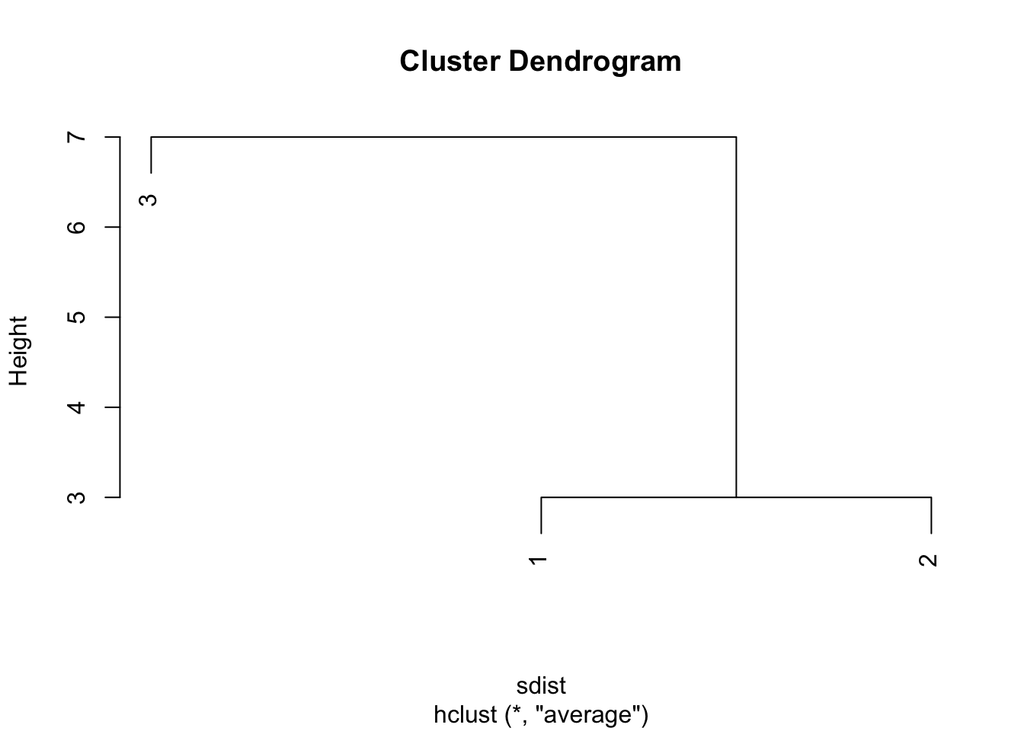

```r
# Perform hierarchical clustering on the distance matrix and plot it
clust <- hclust(sdist, method = "average")
plot(clust)
```

```r
# Pattern matching with mismatches
a = DNAString("TAGCTTATCAGACTGATGTTGACAGATCGGAAGAGCACACGTCTGAACTCC")
b = DNAString("AAGATCGGAAGAGCACACGTCT")

# ?matchPattern
# Find b in a, allowing up to 1 mismatch
matchPattern(b, a, max.mismatch = 1)
```

```
## Views on a 51-letter DNAString subject
## subject: TAGCTTATCAGACTGATGTTGACAGATCGGAAGAGCACACGTCTGAACTCC
## views:
##       start end width
##   [1]    23  44    22 [CAGATCGGAAGAGCACACGTCT]
```

```r
a
```

```
## 51-letter DNAString object
## seq: TAGCTTATCAGACTGATGTTGACAGATCGGAAGAGCACACGTCTGAACTCC
```

```r
# Find exact matches of "CGT" in a
matchPattern("CGT", a)
```

```
## Views on a 51-letter DNAString subject
## subject: TAGCTTATCAGACTGATGTTGACAGATCGGAAGAGCACACGTCTGAACTCC
## views:
##       start end width
##   [1]    40  42     3 [CGT]
```

```r
# Find matches of "CGT" allowing 1 mismatch
matchPattern("CGT", a, max.mismatch=1)
```

```
## Views on a 51-letter DNAString subject
## subject: TAGCTTATCAGACTGATGTTGACAGATCGGAAGAGCACACGTCTGAACTCC
## views:
##       start end width
##   [1]     4   6     3 [CTT]
##   [2]    17  19     3 [TGT]
##   [3]    28  30     3 [CGG]
##   [4]    40  42     3 [CGT]
```

```r
# Store the match object and extract its properties
m = matchPattern("CGT", a, max.mismatch=1)
m
```

```
## Views on a 51-letter DNAString subject
## subject: TAGCTTATCAGACTGATGTTGACAGATCGGAAGAGCACACGTCTGAACTCC
## views:
##       start end width
##   [1]     4   6     3 [CTT]
##   [2]    17  19     3 [TGT]
##   [3]    28  30     3 [CGG]
##   [4]    40  42     3 [CGT]
```

```r
start(m)  # Start positions of matches
```

```
## [1]  4 17 28 40
```

```r
end(m)    # End positions of matches
```

```
## [1]  6 19 30 42
```

```r
length(m) # Number of matches found
```

```
## [1] 4
```

```r
# Just count the matches without returning their coordinates
countPattern("CGT", a, max.mismatch=1)
```

```
## [1] 4
```

### Dictionaries and Position Weight Matrices (PWM)

For more complex matching, you can match multiple patterns at once using dictionaries, or score sequences using a PWM.

```r
## multiple matching
a = DNAString("ACGTACGTACGC")
# Create a dictionary of multiple patterns to search for simultaneously
dict0 = PDict(c("CGT", "ACG"))
# Find all occurrences of the dictionary patterns in the subject sequence
mm = matchPDict(dict0, a)
mm
```

```
## MIndex object of length 2
## [[1]]
## IRanges object with 2 ranges and 0 metadata columns:
##           start       end     width
##       <integer> <integer> <integer>
##   [1]         2         4         3
##   [2]         6         8         3
##
## [[2]]
## IRanges object with 3 ranges and 0 metadata columns:
##           start       end     width
##       <integer> <integer> <integer>
##   [1]         1         3         3
##   [2]         5         7         3
##   [3]         9        11         3
```

```r
mm[[1]] # Matches for the first dictionary item ("CGT")
```

```
## IRanges object with 2 ranges and 0 metadata columns:
##           start       end     width
##       <integer> <integer> <integer>
##   [1]         2         4         3
##   [2]         6         8         3
```

```r
mm[[2]] # Matches for the second dictionary item ("ACG")
```

```
## IRanges object with 3 ranges and 0 metadata columns:
##           start       end     width
##       <integer> <integer> <integer>
##   [1]         1         3         3
##   [2]         5         7         3
##   [3]         9        11         3
```

```r
## matching using PWM (Position Weight Matrix)
# Define a manual PWM (4 rows for A,C,G,T and columns representing positions)
motif = matrix(c(0.97, 0.01, 0.01, 0.01, 0.1, 0.5, 0.39, 0.01, 0.01, 0.05, 0.5, 0.44), nrow=4)
rownames(motif) = c("A", "C", "G", "T")
motif
```

```
##   [,1] [,2] [,3]
## A 0.97 0.10 0.01
## C 0.01 0.50 0.05
## G 0.01 0.39 0.50
## T 0.01 0.01 0.44
```

```r
a = DNAString("ACGTACGTACTC")
# Find sequence regions that match the PWM well enough
matchPWM(motif, a)
```

```
## Views on a 12-letter DNAString subject
## subject: ACGTACGTACTC
## views:
##       start end width
##   [1]     1   3     3 [ACG]
##   [2]     5   7     3 [ACG]
##   [3]     9  11     3 [ACT]
```

```r
# Count how many regions match the PWM
countPWM(motif, a)
```

```
## [1] 3
```

```r
# Score the sequence against the PWM starting at specific positions (1 through 10)
PWMscoreStartingAt(motif, a, 1:10)
```

```
##  [1] 1.97 0.84 0.03 0.16 1.97 0.84 0.03 0.16 1.91 0.07
```

### XStringViews vs. DNAStringSet

`Views` define specific segments of a *single* sequence without duplicating it in memory. `DNAStringSet` is a collection of distinct sequences.

```r
######### multiple strings: XStringViews
a = DNAString("ACGTACGTACTC")
# Create 'Views' on sequence 'a', defining three distinct windows
a2 = Views(a, start=c(1,5,8), end=c(3,8,12))
a2
```

```
## Views on a 12-letter DNAString subject
## subject: ACGTACGTACTC
## views:
##       start end width
##   [1]     1   3     3 [ACG]
##   [2]     5   8     4 [ACGT]
##   [3]     8  12     5 [TACTC]
```

```r
subject(a2) # The underlying base sequence the views reference
```

```
## 12-letter DNAString object
## seq: ACGTACGTACTC
```

```r
length(a2)  # Number of views
```

```
## [1] 3
```

```r
start(a2)   # Start coordinates
```

```
## [1] 1 5 8
```

```r
end(a2)     # End coordinates
```

```
## [1]  3  8 12
```

```r
# Calculate frequencies across all views
alphabetFrequency(a2, baseOnly=TRUE)
```

```
##      A C G T other
## [1,] 1 1 1 0     0
## [2,] 1 1 1 1     0
## [3,] 1 2 0 2     0
```

```r
a2
```

```
## Views on a 12-letter DNAString subject
## subject: ACGTACGTACTC
## views:
##       start end width
##   [1]     1   3     3 [ACG]
##   [2]     5   8     4 [ACGT]
##   [3]     8  12     5 [TACTC]
```

```r
# Logical check on the views
a2 == DNAString("ACGT")
```

```
## [1] FALSE  TRUE FALSE
```

```r
toString(a2)
```

```
## [1] "ACG, ACGT, TACTC"
```

```r
## DNAStringSet
a = DNAString("ACGTACGTACTC")
# Instead of views, create a distinct set of strings extracted from 'a'
a2 = DNAStringSet(a, start=c(1,5,9), end=c(4,8,12))
a2
```

```
## DNAStringSet object of length 3:
##     width seq
## [1]     4 ACGT
## [2]     4 ACGT
## [3]     4 ACTC
```

```r
a2[[1]] # Access the first string in the set
```

```
## 4-letter DNAString object
## seq: ACGT
```

```r
alphabetFrequency(a2, baseOnly=TRUE)
```

```
##      A C G T other
## [1,] 1 1 1 1     0
## [2,] 1 1 1 1     0
## [3,] 1 2 0 1     0
```

### Operations Allowed on StringSets but not Views

Certain mathematical set operations and vectorized matching functions are only designed for `StringSet` objects.

```r
###### Operations only allowed for StringSet but not StringViews
a = DNAString("ACGTACGTACTC")
a1 = DNAStringSet(a, start=c(1,5,9), end=c(4,8,12))
a1
```

```
## DNAStringSet object of length 3:
##     width seq
## [1]     4 ACGT
## [2]     4 ACGT
## [3]     4 ACTC
```

```r
unique(a1) # Returns unique sequences in the set
```

```
## DNAStringSet object of length 2:
##     width seq
## [1]     4 ACGT
## [2]     4 ACTC
```

```r
a2 = Views(a, start=c(1,5,9), end=c(4,8,12))
a2
```

```
## Views on a 12-letter DNAString subject
## subject: ACGTACGTACTC
## views:
##       start end width
##   [1]     1   4     4 [ACGT]
##   [2]     5   8     4 [ACGT]
##   [3]     9  12     4 [ACTC]
```

```r
# unique(a2) # Works only for Sets, running this on Views generates an error

a1 = Views(a, start=c(1,9), end=c(4,12))
a1
```

```
## Views on a 12-letter DNAString subject
## subject: ACGTACGTACTC
## views:
##       start end width
##   [1]     1   4     4 [ACGT]
##   [2]     9  12     4 [ACTC]
```

```r
a2 = Views(a, start=c(1), end=c(4))
a2
```

```
## Views on a 12-letter DNAString subject
## subject: ACGTACGTACTC
## views:
##       start end width
##   [1]     1   4     4 [ACGT]
```

```r
# setdiff(a1, a2) ## this will generate error because Views don't support set algebra
# union(a1, a2)   ## error

### set operations are allowed for StringSet
a1 = DNAStringSet(a, start=c(1,9), end=c(4,12))
a1
```

```
## DNAStringSet object of length 2:
##     width seq
## [1]     4 ACGT
## [2]     4 ACTC
```

```r
a2 = DNAStringSet(a, start=c(1), end=c(4))
a2
```

```
## DNAStringSet object of length 1:
##     width seq
## [1]     4 ACGT
```

```r
setdiff(a1, a2) # Find sequences in a1 not in a2
```

```
## DNAStringSet object of length 1:
##     width seq
## [1]     4 ACTC
```

```r
union(a1, a2)   # Combine unique sequences from a1 and a2
```

```
## DNAStringSet object of length 2:
##     width seq
## [1]     4 ACGT
## [2]     4 ACTC
```

```r
####### matching for multiple strings
a = DNAString("ACGTACGTACTC")
a2 = DNAStringSet(a, start=c(1,5,9), end=c(4,8,12))
a2
```

```
## DNAStringSet object of length 3:
##     width seq
## [1]     4 ACGT
## [2]     4 ACGT
## [3]     4 ACTC
```

```r
# Vectorized match pattern - searches for "CG" across all strings in the set
vv = vmatchPattern("CG", a2)
vv
```

```
## MIndex object of length 3
## [[1]]
## IRanges object with 1 range and 0 metadata columns:
##           start       end     width
##       <integer> <integer> <integer>
##   [1]         2         3         2
##
## [[2]]
## IRanges object with 1 range and 0 metadata columns:
##           start       end     width
##       <integer> <integer> <integer>
##   [1]         2         3         2
##
## [[3]]
## IRanges object with 0 ranges and 0 metadata columns:
##        start       end     width
##    <integer> <integer> <integer>
```

```r
vv[[1]] # Matches found in the first string
```

```
## IRanges object with 1 range and 0 metadata columns:
##           start       end     width
##       <integer> <integer> <integer>
##   [1]         2         3         2
```

```r
## doesn't work for Views
a2 = Views(a, start=c(1,5,9), end=c(4,8,12))
a2
```

```
## Views on a 12-letter DNAString subject
## subject: ACGTACGTACTC
## views:
##       start end width
##   [1]     1   4     4 [ACGT]
##   [2]     5   8     4 [ACGT]
##   [3]     9  12     4 [ACTC]
```

```r
# vv = vmatchPattern("CG", a2) # Generates an error, vmatchPattern requires a StringSet
```

### BSgenome and Reference Data Packages

`BSgenome` packages contain full reference genomes. This demonstrates how to interact with full chromosomes.

```r
#####################################################
## Now show BSgenome and data packages
#####################################################
# Note: Ensure BSgenome and BSgenome.Hsapiens.UCSC.hg38 are installed
library(BSgenome)

# List all available genomes you have installed
available.genomes()

# Load the Human reference genome (hg38)
library(BSgenome.Hsapiens.UCSC.hg38)
# List objects available within this package
ls("package:BSgenome.Hsapiens.UCSC.hg38")

Hsapiens
Hsapiens$chr1 # Extract full sequence for Chromosome 1

seqnames(Hsapiens) # List all chromosome names
seqlengths(Hsapiens)[1:25] # View the length (in bp) of the first 25 chromosomes

# Slice out a specific 11bp region from Chromosome 1
Hsapiens$chr1[100000000:100000010]

# Calculate the base frequencies across all of Chromosome 1
alphabetFrequency(Hsapiens$chr1, baseOnly=TRUE)
# Get the relative proportions of each base on Chromosome 1
alphabetFrequency(Hsapiens$chr1, baseOnly=TRUE) / length(Hsapiens$chr1)

# Find all occurrences of the "CG" dinucleotide on Chromosome 1
mm = matchPattern("CG", Hsapiens$chr1)
length(mm) # Count of CG sites
mm
```

### Masked Genomes and SNPs

Masked genomes block out repetitive or uncharacterized regions. SNP packages inject known variant locations into the reference genome.

```r
### masking
# Note: Requires BSgenome.Hsapiens.UCSC.hg38.masked
library(BSgenome.Hsapiens.UCSC.hg38.masked)

# Accessing a masked chromosome reveals active masks (e.g., against repeats)
Hsapiens[["chr1"]]
Hsapiens$chr1

## SNPs
# List available and installed SNP packages
available.SNPs()
installed.SNPs()

# Inject SNPs into the reference genome to create a variant-aware genome object
# (Commented out because the exact dbSNP package needs to be installed locally)
# SnpHsapiens <- injectSNPs(Hsapiens, "SNPlocs.Hsapiens.dbSNP.20120608")
# SnpHsapiens

# snpcount(SnpHsapiens) # Count SNPs injected
# head(snplocs(SnpHsapiens, "chr1")) # View the first few SNP locations on chr1

IUPAC_CODE_MAP
```

### Genomic Ranges and Alignments

Using `GenomicRanges` and `GenomicAlignments` to find sequencing reads that span or support specific biological events (like splice junctions).

```r
# Find reads supporting the junction identified above, at position
# 19653707 + 66M = 19653773 of chromosome 14

library(GenomicRanges)
library(GenomicAlignments)
library(Rsamtools)

## our 'region of interest' (ROI)
IRanges(start = 19653773, width=1)
# Create a GRanges object mapping the ROI to chromosome 14
roi <- GRanges("chr14", IRanges(start = 19653773, width=1))
roi

## sample data
# Load sample BAM file containing RNA-seq data
library('RNAseqData.HNRNPC.bam.chr14')
bf <- BamFile(RNAseqData.HNRNPC.bam.chr14_BAMFILES[[1]], asMates=TRUE)
bf

## alignments, junctions, overlapping our roi
# ?readGAlignmentsList
# Read paired-end alignments into memory
paln <- readGAlignmentsList(bf)
paln

# ?summarizeJunctions
# Extract and summarize splice junctions from the alignments
j <- summarizeJunctions(paln, with.revmap=TRUE)
j

# Subset junctions to find only the ones overlapping our Region of Interest
j_overlap <- j[j %over% roi]
j_overlap

## supporting reads
# Use the reverse map to extract the actual reads that support the junction at the ROI
paln[j_overlap$revmap[[1]]]
```

### Variant Annotation

This final chunk takes variants from a standard VCF file and determines their functional impact by intersecting them with a known database of gene models.

```r
# Read variants from a VCF file, and annotate with respect to a known gene model

## input variants
library(VariantAnnotation)
# Locate a sample VCF file shipped with the VariantAnnotation package
fl <- system.file("extdata", "chr22.vcf.gz", package="VariantAnnotation")
# Read the VCF file, specifying it aligns to human genome build hg19
vcf <- readVcf(fl, "hg19")
# Subset to focus only on chromosome 22
seqlevels(vcf) <- "chr22"

## known gene model
# Load the reference database of transcripts for hg19
library(TxDb.Hsapiens.UCSC.hg19.knownGene)

# Intersect the variants (from the VCF) with the known gene models (TxDb)
# Specifically look for coding variants (e.g., synonymous, non-synonymous)
coding <- locateVariants(
  rowRanges(vcf),
  TxDb.Hsapiens.UCSC.hg19.knownGene,
  CodingVariants()
)

# View the resulting variant annotations
head(coding)
```